# Does Mileage depend on transmission type

Shubham Kalra

Friday, April 10, 2015

=======================================

In 1974, Motor Trend US magazine came out with data set which comprised of fuel consumptions and 10 other aspects of automobile performance for 32 automobiles. Today, We look back to find parameters which determined the mileage of a car at that point of time. And quantify, whether cars with manual transmission or cars with automatic transmission had a better mileage.

This article is written keeping in mind audience with statistical know how. One can replicate the study using code snippets provided alongside. To keep the analysis more organized and less overwhelming, I have divided into various sub-sections. Lets jump right into it.

### Exploratory Data Analysis

The data comprises of fuel consumption and 10 aspects of automobile design and performance for 32 automobiles (1973–74 models).

**mtcars is data frame with 32 observations on 11 variables**

| Variable | Definition |
| --- | --- |
| mpg | Miles/(US) gallon |
| cyl | Number of cylinders |
| disp | Displacement (cu.in.) |
| hp | Gross horsepower |
| drat | Rear axle ratio |
| wt | Weight (lb/1000) |
| qsec | 1/4 mile time |
| vs | V/S |
| am | Transmission (0 = automatic, 1 = manual) |
| gear | Number of forward gears |
| carb | Number of carburetors |

We start by importing data into a new variable, `cars`, and then display first few observations of `cars`.

```r
data(mtcars)
#importing data in a variable
cars <- mtcars
head(cars)
```

```
##                    mpg cyl disp  hp drat    wt  qsec vs am gear carb
## Mazda RX4         21.0   6  160 110 3.90 2.620 16.46  0  1    4    4
## Mazda RX4 Wag     21.0   6  160 110 3.90 2.875 17.02  0  1    4    4
## Datsun 710        22.8   4  108  93 3.85 2.320 18.61  1  1    4    1
## Hornet 4 Drive    21.4   6  258 110 3.08 3.215 19.44  1  0    3    1
## Hornet Sportabout 18.7   8  360 175 3.15 3.440 17.02  0  0    3    2
## Valiant           18.1   6  225 105 2.76 3.460 20.22  1  0    3    1
```

One may also run `summary(cars)` to get more interesting statistics about each variable. We observe that few variables such as ‘Number of Cylinders’, ‘Number of forward gears’, etc. are categorical variables. We convert those to [factors](http://www.stat.berkeley.edu/~s133/factors.html).

```r
# Changing classifying variables from numeric values to factor

cars$cyl <- factor(cars$cyl)
cars$vs <- factor(cars$vs)
cars$am <- factor(cars$am)
cars$gear <- factor(cars$gear)
cars$carb <- factor(cars$carb)
```

### Data Visualizations

Next, we visualize the data to understand the behaviour of the response variable.

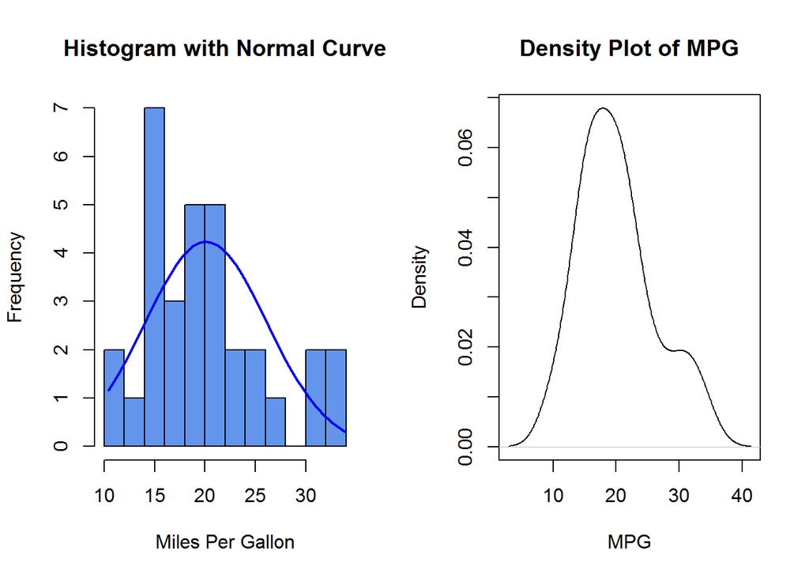

- Curve shows a near Normal Distribution

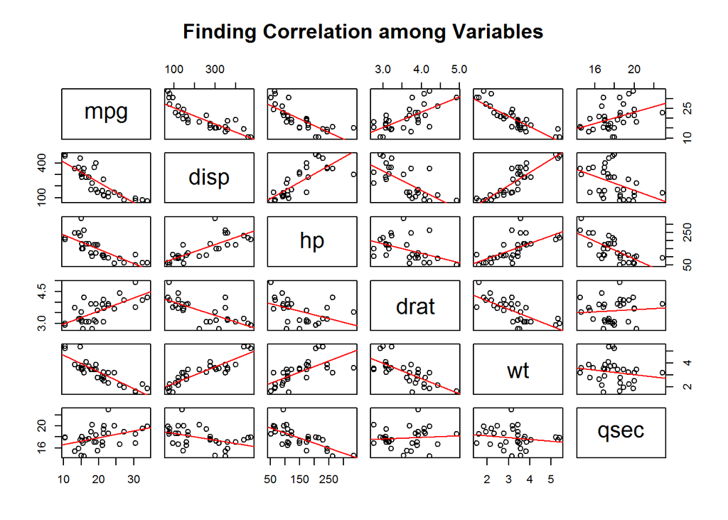

- Above scatter plot matrix shows the correlation between each variables.
- We see a high correlation between response variables and predictor variables.
- Also, we see correlations among predictor variables.

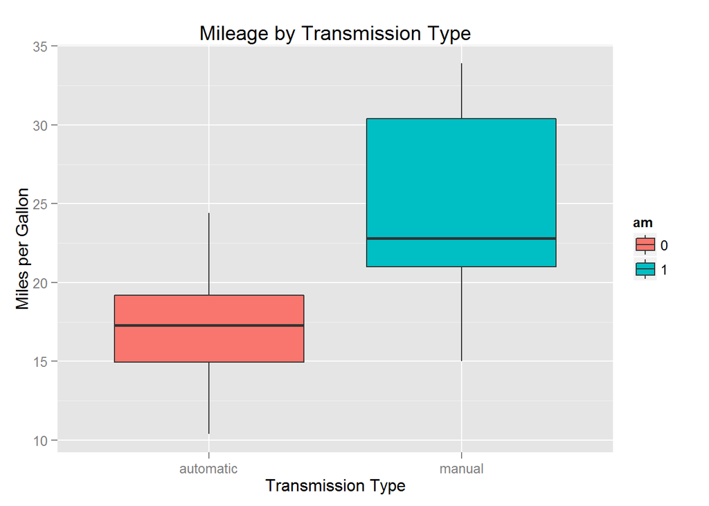

From the box plot, we observe the following:

- Manual transmission is better than Automatic transmission.
- We see the range of values and check for outliers.

Code for the above plots are available on my github repository, you can fork the entire code [here](https://github.com/shubhamkalra27/mtcars-analysis/blob/master/mtcars.R).

Next we will check if they are statistically significant using a [two sample t-test](http://www.itl.nist.gov/div898/handbook/eda/section3/eda353.htm).

### Two Sample t-test

Two-sample t-test is applied to compare whether the average difference between two groups is really significant or if it is due instead to random chance.

```r
t.test(mpg~am, data = cars)
```

```
##
##  Welch Two Sample t-test
##
## data:  mpg by am
## t = -3.7671, df = 18.332, p-value = 0.001374
## alternative hypothesis: true difference in means is not equal to 0
## 95 percent confidence interval:
##  -11.280194  -3.209684
## sample estimates:
## mean in group 0 mean in group 1
##        17.14737        24.39231
```

**Interpretation**  
From the above output, we reject the null hypothesis with a p-value of **0.001374**, and say that there is a statistically significant difference in mean mileage between manual transmission and automatic transmission.

We will now Quantify that difference using Regression techniques.

### Simple linear regression

Our first regression model is to explain the `mpg` variability with the `am` only.

```r
model1 <- lm( mpg~am ,data=mtcars); summary(model1)
```

```
##
## Call:
## lm(formula = mpg ~ am, data = mtcars)
##
## Residuals:
##     Min      1Q  Median      3Q     Max
## -9.3923 -3.0923 -0.2974  3.2439  9.5077
##
## Coefficients:
##             Estimate Std. Error t value Pr(>|t|)
## (Intercept)   17.147      1.125  15.247 1.13e-15 ***
## am             7.245      1.764   4.106 0.000285 ***
## ---
## Signif. codes:  0 '***' 0.001 '**' 0.01 '*' 0.05 '.' 0.1 ' ' 1
##
## Residual standard error: 4.902 on 30 degrees of freedom
## Multiple R-squared:  0.3598, Adjusted R-squared:  0.3385
## F-statistic: 16.86 on 1 and 30 DF,  p-value: 0.000285
```

**Interpretation of simple linear regression**

- Intercept value implies that cars with Automatic Transmission have on average **17.147** MPG
- Coefficient of the parameter `am` implies that Manual transmission cars add on average **7.245** MPG’s more to the Automatic car’s mean value.
- Adj R square value says, that only **33.85%** of deviation in model can be explained by the current model with one predictor.

> Before making any conclusions on the effect of transmission type on mileage, we look at the impact of other variables on mileage

### Multiple Regression

Next, we would like to determine dependence of other variables on Mileage. To find out which preditor variables to use in our model, we run a Stepwise regression to identify useful subset of predictors.

```r
nullModel <- lm (mpg ~ 1 , data =cars) # model with no predictor variables.

fullModel <- lm (mpg ~ . , data = cars) # model with all variables added as predictor variables.

bestModel <- step(fullModel, nullModel, direction="both", k=log(nrow(cars))) #both direction BIC step model

bestModel$call  #display formula
```

```
## Start:  AIC=101.32
## mpg ~ cyl + disp + hp + drat + wt + qsec + vs + am + gear + carb
##
##        Df Sum of Sq    RSS     AIC
## - carb  5   13.5989 134.00  87.417
## - gear  2    3.9729 124.38  95.428
## - cyl   2   10.9314 131.33  97.170
## - am    1    1.1420 121.55  98.157
## - qsec  1    1.2413 121.64  98.183
## - drat  1    1.8208 122.22  98.335
## - vs    1    3.6299 124.03  98.806
## - disp  1    9.9672 130.37 100.400
## <none>              120.40 101.321
## - wt    1   25.5541 145.96 104.014
## - hp    1   25.6715 146.07 104.040
##
## Step:  AIC=87.42
## mpg ~ cyl + disp + hp + drat + wt + qsec + vs + am + gear
##
##        Df Sum of Sq    RSS    AIC
## - gear  2    5.0215 139.02 81.662
## - cyl   2   12.5642 146.57 83.353
## - disp  1    0.9934 135.00 84.187
## - drat  1    1.1854 135.19 84.233
## - vs    1    3.6763 137.68 84.817
## - qsec  1    5.2634 139.26 85.184
## - am    1   11.9255 145.93 86.679
## <none>              134.00 87.417
## - wt    1   19.7963 153.80 88.360
## - hp    1   22.7935 156.79 88.978
##
## Step:  AIC=81.66
## mpg ~ cyl + disp + hp + drat + wt + qsec + vs + am
##
##        Df Sum of Sq    RSS    AIC
## - cyl   2   10.4247 149.45 77.045
## - drat  1    0.9672 139.99 78.418
## - disp  1    1.5483 140.57 78.551
## - vs    1    2.1829 141.21 78.695
## - qsec  1    3.6324 142.66 79.022
```

[output cut: 44 more lines]

```
##        Df Sum of Sq    RSS    AIC
## - hp    1     9.219 169.29 67.170
## <none>              160.07 68.844
## - qsec  1    20.225 180.29 69.186
## - am    1    25.993 186.06 70.193
## - wt    1    78.494 238.56 78.147
##
## Step:  AIC=67.17
## mpg ~ wt + qsec + am
##
##        Df Sum of Sq    RSS    AIC
## <none>              169.29 67.170
## - am    1    26.178 195.46 68.306
## - qsec  1   109.034 278.32 79.614
## - wt    1   183.347 352.63 87.187
```

```
## lm(formula = mpg ~ wt + qsec + am, data = cars)
```

- The variables mentioned by bestModel are most useful set of predictors.
- The final model `bestModel` contains three predictors, wt(weight), qsec(1/4 mile time) and am(Transmission).

Summarizing the new Model.

```r
summary(bestModel)
```

```
##
## Call:
## lm(formula = mpg ~ wt + qsec + am, data = cars)
##
## Residuals:
##     Min      1Q  Median      3Q     Max
## -3.4811 -1.5555 -0.7257  1.4110  4.6610
##
## Coefficients:
##             Estimate Std. Error t value Pr(>|t|)
## (Intercept)   9.6178     6.9596   1.382 0.177915
## wt           -3.9165     0.7112  -5.507 6.95e-06 ***
## qsec          1.2259     0.2887   4.247 0.000216 ***
## am1           2.9358     1.4109   2.081 0.046716 *
## ---
## Signif. codes:  0 '***' 0.001 '**' 0.01 '*' 0.05 '.' 0.1 ' ' 1
##
## Residual standard error: 2.459 on 28 degrees of freedom
## Multiple R-squared:  0.8497, Adjusted R-squared:  0.8336
## F-statistic: 52.75 on 3 and 28 DF,  p-value: 1.21e-11
```

**Interpretation of Multiple Regression**

- Adjusted R square value signifies that **83.36%** of the variance can be explained by this model, which is a significant improvement over first model.
- 1000 pound increase in `wt`(weight) of a car, keeping all other variables constant, decreases MPG by **3.917**
- 1 unit change in `qsec`(1/4 mile time), with all other variables constant, increases MPG by **1.226**
- Coefficient for `am` signifies that, manual transmission cars have an average MPG of **2.936** more than that of automatic transmission cars.
- The p-value for `am` is `0.046` which makes it a weakest predictor of mileage.

### Conclusion

Mileage (mpg), when modeled with just one predictor `am`, we get manual transmission to yield an average of `7.245`mpg higher than automatic transmission. Here, only **33.85%** of variance could be explained.

Multiple regression on stepwise regressed variables defines **83.36**% of variability. `wt` and `qsec` have [confounded](http://en.wikipedia.org/wiki/Confounding) the relationship between `am` and `mpg`. Manual transmission in this model increases mileage by only `2.936 mpg`

#### References

1. mtcars dataset https://stat.ethz.ch/R-manual/R-devel/library/datasets/html/mtcars.html
2. Density Plot. http://www.statmethods.net/graphs/density.html
3. Analysis on mtcars dataset to predict mpg http://varianceexplained.org/RData/code/code_lesson3/
4. BoxPlot using ggplot2 http://www.statmethods.net/advgraphs/ggplot2.html
5. More on factors http://www.stat.berkeley.edu/~s133/factors.html
6. Confounding Variables http://en.wikipedia.org/wiki/Confounding/
7. two-sample t test http://www.isixsigma.com/tools-templates/hypothesis-testing/making-sense-two-sample-t-test/
8. Coursera regmods https://github.com/sefakilic/coursera-regmods/

You can access the code for the above analysis at my github repository. https://github.com/shubhamkalra27/mtcars-analysis

[follow author on Twitter](https://twitter.com/shubhamkalra27)